# Lecture 3

# Quick recap

So far, we have learned about:

What happens to a population when there are no evolutionary forces (or drift) present. H-W equilibrium

What happens when drift is present (Wright-Fisher).

How we can describe variation across/within a population, and how mutation impacts this quantity.

Today, we’ll keep focusing on mutation, but we’ll also add another layer of complication - a comparison with a second population.

This can be the ancestor, or a sister species, or a distantly related one.

Key - how different are the populations?

# Rate of evolution

Let’s start by thinking about how rapidly a population becomes different from its ancestor.

As a population evolves in WF + $\mu$, new mutations appear and may be fixed, old variants may be lost or fixed due to drift.

Over time - two identical populations become different.

## Visualizing in simulations:

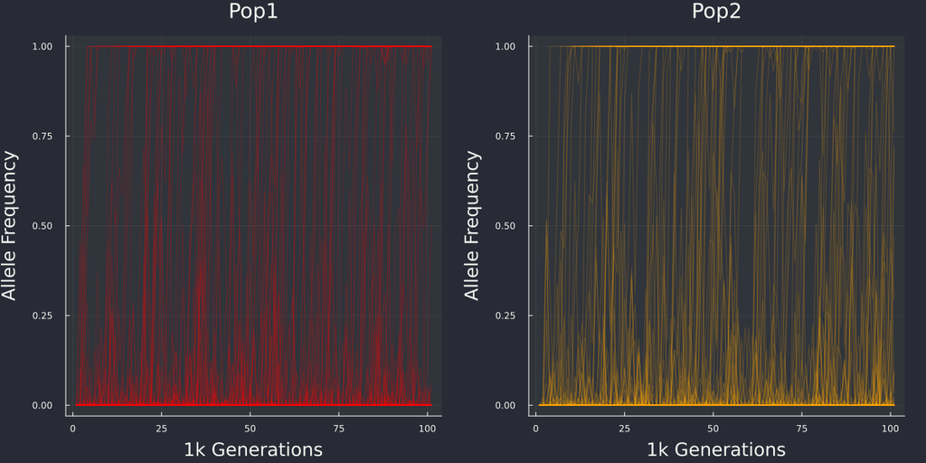

## What is divergence?

To answer this question we first need to consider what it means for two sequences to be diverged.

Divergence is often measured as a simple pairwise distance between two sequences:

```
>species_1
ATgcATgATTtA
>species_2
ATcgATcATTcA
```

Raw differences: 4

Per/site: 0.3

But what if there’s variation w/in populations?

## In simulations: simplest

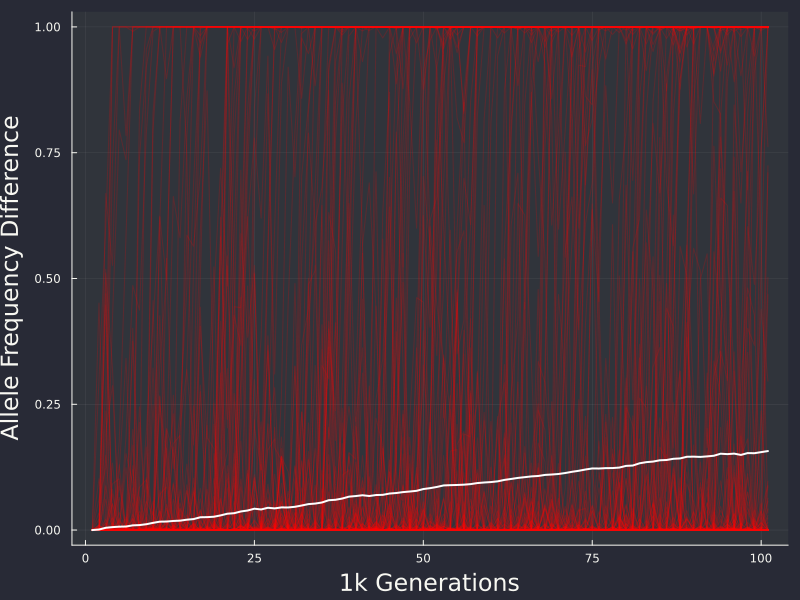

## AFD (allele frequency difference) problems

Seems intuitive, but does not scale linearly with time.

Remember fastest change when allele frequencies are intermediate.

Swing of 0.1 easily happens when allele common - hard when rare.

So, which takes longer to evolve: 0.4-0.6 or 0.1-0.3?

## A better approach:

The pairwise divergence between two sequences is *d*, measuring the probability two sites sampled are different.

Let *k* be the number of substitutions fixed per generation.

So, comparing a random sequence from an ancestor to a descendent:

$$E[d_t] = kt+\theta_{Anc}$$

$\theta_{Anc}$ accounts for the fact that there is genetic variation in the ancestor, so it depends on *who* you compare the descendant to.

If $t>>1$, then $\theta_{Anc}$ is comparably small and can be ignored.

## *d* in simulations:

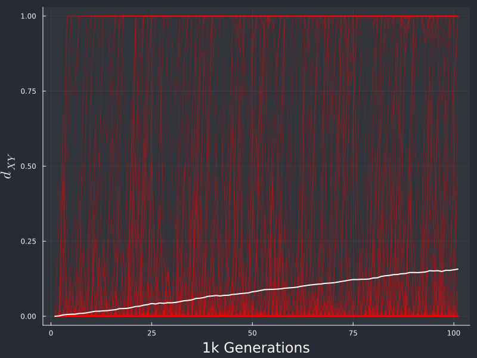

## $d_{XY}$ - one estimate of *d*

We can estimate *d* with $d_{XY}$:

$$d_{XY}=p_1(1-p_2)+(1-p_1)p_2$$

Where $p_i$ is the allele frequency in the $i^{th}$ population.

Just the probability that if two alleles grabbed at random mismatch, when alleles biallelic and polymorphic.

Often makes sense to ignore polymorphism for highly diverged species.

Infinite sites model - mutations are never repeated, ancestral variation is lost, so only comparing differences per base pair at fixed substitutions.

## Rate of allele fixation: what is $k$?

Recall that any new allele that’s starting at frequency $\frac{1}{2N_E}$ also has a probability of $\frac{1}{2N_E}$ of becoming fixed.

Let’s say there are lots of these mutations, each with probability of $\frac{1}{2N_E}$ of becoming fixed. How long do we have to wait until an allele is fixed?

If they evolve independently, this is just the `geometric` probability distribution. We know that the $E[geom(\lambda)] = \frac{1}{\lambda}$ - the average waiting time for a success is inverse to the rate.

## Geometric distribution: dice example

Each trial, probability of getting 6 is $\frac{1}{6}$. On average, 6 tries until you get it.

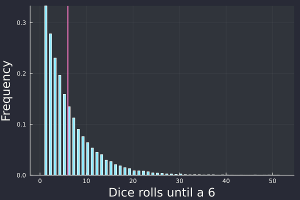

## Cntd.

So, on average of $2N_E$ generations for a mutation to fix, and each generation $\frac{1}{2N_E}$ mutations fix.

That tells us the rate of fixation, assuming there are infinite mutations.

## But there are not infinite mutations

How many new alleles come in every generation?

There are $2N_E$ copies of the genome. Then - there are $2N_E\mu$ new mutations every generation.

## Putting it together - the basics of neutral theory

If we put all of this together, the rate of fixing mutations becomes quite predictable:

Every generation there are $2N_E\mu$ mutations coming in that are fixed at a rate of $\frac{1}{2N_E}$

The neutral evolutionary rate is therefore:

$$k=\frac{1}{2N_E}2N_E\mu = \mu$$

So: $d=\mu t$

## Back to simulations

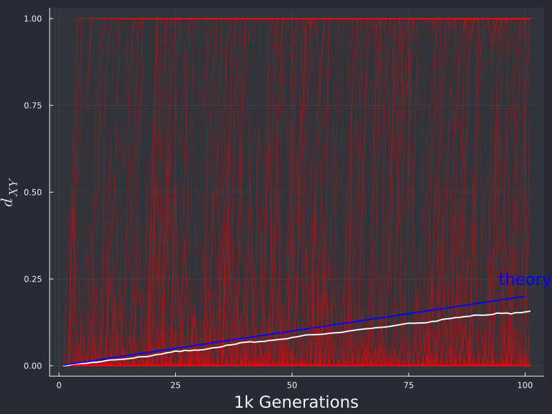

## Neutral theory

The result that evolutionary rate should be equal to the neutral mutation rate is at the core of Neutral Theory.

Pioneered by Motoo Kimura and Tomoko Ohta, with lots of subsequent results. (KIMURA 1968; Ohta and Gillespie 1996; Kern and Hahn 2018)

The idea is that *most* mutations are expected to be neutral.

Therefore *most* divergence is going to be described simply by the neutral mutation rate.

Is this true?

## Support for Neutral Theory

Some nucleotide and amino acid sequences show a constant rate of evolution (Blair Hedges and Kumar 2003).

[figure not shown]

## More evidence

The distribution of fitness effects (DFE) of new mutations *looks* like it supports Neutral Theory (Sanjuán, Moya, and Elena 2004).

[figure not shown]

## Evidence against neutral theory

Long run: substitution rates are *not* constant across species (Lynch et al. 2016)

[figure not shown]

## More evidence against:

Substitution rates are not even the same across a genome (Mackay et al. 2012)

[figure not shown]

## Many places we simplified

WF expectation is for a steady state - populations frequently undergo bottlenecks.

Selection causes signals identical to bottlenecks - could perpetually keep $N_E$ depressed.

Assumption is that the loci used to calculate $\pi$ are independent - they are not.

WF expectation from simple model of mutation - mutations are more complex.

## More complex models of mutation

The model of mutation we have used so far is the simplest possible - a single parameter ($\mu$) with equal backwards and forwards mutation rates.

Works great for the ephemeral “loci” before we knew what genes actually were.

More realistically: we need to consider a molecular model.

## Jukes-Cantor (JC69)

One step up from our biallelic model is recognizing that there are, actually, four bases possible.

[figure not shown]

## A series of increasingly more complicated models

More complex models have more parameters, distinguishing between transitions and transversion ((Kimura 1981) K81).

And allowing for different expected base frequencies (Felsenstein 1981).

And specifying mutation/base frequencies for the type of sequence (HIV, MT models, etc)

Up to each mutation rate/base rate being specified.

That’s 12 mutation rates and four bases, for 16 parameters!

## Most practical model: GTR

The General Time Reversible model still has 10 parameters, but they are simpler: each pair of nucleotides has its own rate.

Time reversible because probability forward and back is the same.

Many more model considerations, especially for phylogenetics!

## Will we use these more complex models?

When possible, we’ll use a single parameter model.

Most practical population genomics approaches, however, will either need you to specify or will fit a molecular model of sequence evolution.

`iqTree2` for instance, has `ModelFinder` which will try to detect the type of sequence and most appropriate evolutionary model.

## Back to divergence

$d$ and $d_{XY}$ are fine estimates when we get rid of that pesky shared variation - $\theta_{Anc}$

But, what if there *is* appreciable shared variation?

## F statistics: $F_{ST}$

Last time we learned about $F_{IS}$, which is an inbreeding coefficient.

You may have thought it stands for “Inbreeding Statistic” - it’s actually “Individual - Subpopulation”

$F_{ST}$ - F statistic for “subpopulation - total population”

How is variation partitioned w/in populations vs between?

## $F_{ST}$ definition, cntd.

$$F_{ST} = \frac{\sigma_S^2}{\sigma_T^2} = \frac{\sigma_S^2}{\bar{p}(1-\bar{p})}$$

Where $\sigma_S^2$ is the variance of the frequency of an allele in sub-populations.

How do you actually calculate it?

Slatkin estimator: if $f_i$ is the frequency of samples from population *i*:

$$F_{ST} = \frac{\pi_{between}-\pi_{within}}{\pi_{between}} = 1- \frac{f_1(p_1q_1)+f_2(p_2q_2)}{(f_1p_1+f_2p_2)(f_1q_1+f_2q_2)}$$

## $F_{ST}$ - really useful!

Studies will frequently look for regions of elevated $F_{ST}$ as regions of divergence.

Neat result from coalescent: $T \approx -\log(1-F_{ST})$

So, can estimate divergence at sites using $F_{ST}$, can look for variation in genome, can look for significant outliers.

Many estimators using various data and approaches.

## Cool use of $F_{ST}$ - PBS

Population Branch Score: test to look for places in genome where some population is much more differentiated than expected.

Requires focal population (1), sister without adaptive pressure (2), and outgroup (3).

$$PBS = \frac{T_{12}+T_{13}-T_{23}}{2}$$

Normally hard to get $T$ - but easy transform from $F_{ST}$.

## EPAS1 and Tibetans

First use case of PBS - identifying adaptive gene for high altitude adaptation (Yi et al. 2010)

[figure not shown]

## Problems with $F_{ST}$

Denominator is total genetic diversity.

Regions of low diversity have higher $F_{ST}$ - even if total allele frequency shift is low!

Same as estimators of diversity - software has various assumptions about missing data, and biases abound.

Turns out - all $F_{ST}$ estimates across a region are strongly affected by rare variants (Bhatia et al. 2013; Berner 2019; Cruickshank and Hahn 2014)

## Example in simulations:

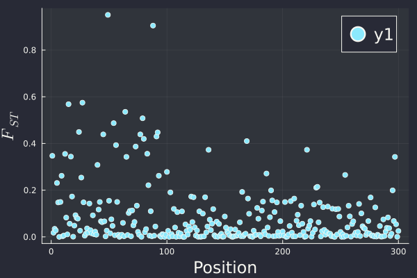

## But!

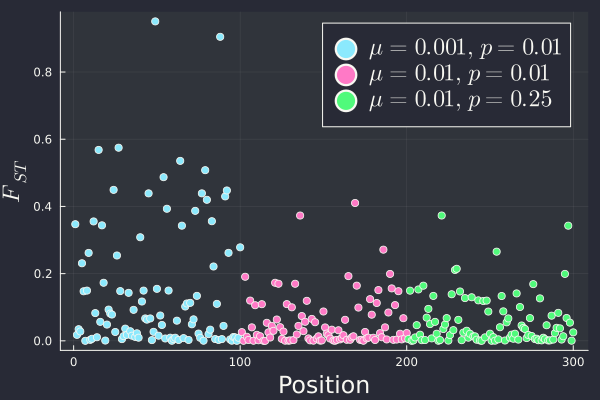

## What about divergence across a gene?

Recognizing that sequences are not all equally likely to evolve leads us to needing to think about different rates of evolution.

A fully neutral sequence might still diverge at the rate of $\mu$, but what about a sequence where mutations are *not* neutral?

Sequence could be constrained - slower divergence, or be under positive selection: faster than neutral.

Even if Neutral Theory is not correct, the Neutral Model is a useful null model to measure against.

## $d_N$, $d_S$

Instead of considering divergence across a whole region, we might want to split among sites that are (presumably) neutral, and sites that may not be.

Generally, synonymous substitutions are unlikely to affect fitness, as they are not contributing to a difference in protein sequence.

On the other hand, changes which lead to a different amino acid (non-synonymous), are more likely to be selected.

## $\omega = \frac{d_N}{d_S}$ - constraint on gene evolution

If a sequence is truly neutral:

$\frac{d_N}{d_S}=1$

If sequence constrained:

$\frac{d_N}{d_S} << 1$

If sequence positively selected:

$\frac{d_N}{d_S} > 1$

## McDonald-Kreitman Test (MK)

The problems of a regular $\frac{d_N}{d_S}$ test can be alleviated by looking at polymorphisms within populations.

$$\begin{cases}
d_S = 2L_S\mu t \\
d_N = 2L_N\mu t \frac{f}{1-\alpha} \\
P_S = L_SN_E\mu k \\
P_N = L_NN_E\mu k f
\end{cases}$$

$\alpha = 1-\frac{d_S}{d_N}\frac{P_N}{P_S}$

## How much evolution is adaptive?

Varies heavily by system and sequence type, but more than you may think! (EYREWALKER 2006)

[figure not shown]

## How to estimate?

We’ll talk Thursday, but many tools, we’ll focus on `PaML` .

Need trees, sequences (amino acid *and* nucleotide) - so many tools to learn.

If you are worried about your laptop holding up - let me know! We’ll try to get you on HPC ahead of class.

## References

Berner, Daniel. 2019. “Allele Frequency Difference AFDAn Intuitive Alternative to FST for Quantifying Genetic Population Differentiation.” *Genes* 10 (4): 308. https://doi.org/10.3390/genes10040308.

Bhatia, Gaurav, Nick Patterson, Sriram Sankararaman, and Alkes L. Price. 2013. “Estimating and Interpreting *F*<sub>ST</sub>: The Impact of Rare Variants.” *Genome Research* 23 (9): 1514–21. https://doi.org/10.1101/gr.154831.113.

Blair Hedges, S., and Sudhir Kumar. 2003. “Genomic Clocks and Evolutionary Timescales.” *Trends in Genetics* 19 (4): 200–206. https://doi.org/10.1016/s0168-9525(03)00053-2.

Cruickshank, Tami E., and Matthew W. Hahn. 2014. “Reanalysis Suggests That Genomic Islands of Speciation Are Due to Reduced Diversity, Not Reduced Gene Flow.” *Molecular Ecology* 23 (13): 3133–57. https://doi.org/10.1111/mec.12796.

EYREWALKER, A. 2006. “The Genomic Rate of Adaptive Evolution.” *Trends in Ecology & Evolution* 21 (10): 569–75. https://doi.org/10.1016/j.tree.2006.06.015.

Felsenstein, Joseph. 1981. “Evolutionary Trees from DNA Sequences: A Maximum Likelihood Approach.” *Journal of Molecular Evolution* 17 (6): 368–76. https://doi.org/10.1007/bf01734359.

Kern, Andrew D, and Matthew W Hahn. 2018. “The Neutral Theory in Light of Natural Selection.” Edited by Sudhir Kumar. *Molecular Biology and Evolution* 35 (6): 1366–71. https://doi.org/10.1093/molbev/msy092.

Kimura, M. 1981. “Estimation of Evolutionary Distances Between Homologous Nucleotide Sequences.” *Proceedings of the National Academy of Sciences* 78 (1): 454–58. https://doi.org/10.1073/pnas.78.1.454.

KIMURA, MOTOO. 1968. “Evolutionary Rate at the Molecular Level.” *Nature* 217 (5129): 624–26. https://doi.org/10.1038/217624a0.

Lynch, Michael, Matthew S. Ackerman, Jean-Francois Gout, Hongan Long, Way Sung, W. Kelley Thomas, and Patricia L. Foster. 2016. “Genetic Drift, Selection and the Evolution of the Mutation Rate.” *Nature Reviews Genetics* 17 (11): 704–14. https://doi.org/10.1038/nrg.2016.104.

Mackay, Trudy F. C., Stephen Richards, Eric A. Stone, Antonio Barbadilla, Julien F. Ayroles, Dianhui Zhu, Sònia Casillas, et al. 2012. “The Drosophila Melanogaster Genetic Reference Panel.” *Nature* 482 (7384): 173–78. https://doi.org/10.1038/nature10811.

Ohta, Tomoko, and John H. Gillespie. 1996. “Development of Neutral and Nearly Neutral Theories.” *Theoretical Population Biology* 49 (2): 128–42. https://doi.org/10.1006/tpbi.1996.0007.

Sanjuán, Rafael, Andrés Moya, and Santiago F. Elena. 2004. “The Distribution of Fitness Effects Caused by Single-Nucleotide Substitutions in an RNA Virus.” *Proceedings of the National Academy of Sciences* 101 (22): 8396–8401. https://doi.org/10.1073/pnas.0400146101.

Yi, Xin, Yu Liang, Emilia Huerta-Sanchez, Xin Jin, Zha Xi Ping Cuo, John E. Pool, Xun Xu, et al. 2010. “Sequencing of 50 Human Exomes Reveals Adaptation to High Altitude.” *Science* 329 (5987): 75–78. https://doi.org/10.1126/science.1190371.